# Case Study: How Does a Bike-Share Navigate Speedy Success?

Adusumalli Jayakrishna

27/01/2022

## Scenario

You are a junior data analyst working in the marketing analyst team at Cyclistic, a bike-share company in Chicago. The director of marketing believes the company’s future success depends on maximizing the number of annual memberships. Therefore, your team wants to understand how casual riders and annual members use Cyclistic bikes differently. From these insights, your team will design a new marketing strategy to convert casual riders into annual members. But first, Cyclistic executives must approve your recommendations, so they must be backed up with compelling data insights and professional data visualizations.

### Objective

Find out how casual riders and annual members use Cyclistic bikes differently so that Your team can use these insights to create recommendations on how to convert casual riders into annual members.

### Data Source

We use the [Cyclistic’s historical trip data](https://divvy-tripdata.s3.amazonaws.com/index.html) to analyze and identify trends.

(Note: The datasets have a different name because Cyclistic is a fictional company. For the purposes of this case study, the datasets are appropriate and will enable you to answer the business questions. The data has been made available by Motivate International Inc. under this [license](https://ride.divvybikes.com/data-license-agreement).)

## Importing required packages

```r
library(tidyverse) # Makes analyzing data easier
library(dplyr) # Used for data manipulation
library(here) # Helps finding files easier
library(skimr) # Used for finding Summary Statistics
library(janitor) # Helps clean data
library(data.table)
library(lubridate) # Used for manipulating Date attributes
library(hms)
```

## Reading data

Reading all the data into a list of data frames and checking each file sizes :-

```r
file_names <- list.files(path="./all_data", pattern=".csv", all.files=TRUE,full.names=TRUE)
print("printing each file size in MB")
data <- list()
n <- 1
for (item in file_names){
  cat("File name ", item)
  data[[n]] = read.csv(item,na.strings=c("","NA"))            # reading all the data where empty strings are recorded as NA
  cat("\n File Size = ")
  print(object.size(data[[n]]),units = "MB")
  cat("Number of rows = ",nrow(data[[n]]))
  cat(" , Number of columns = ",ncol(data[[n]]))
  cat("\n")
  n <- n+1
}
```

```
## [1] "printing each file size in MB"
## File name  ./all_data/202101-divvy-tripdata.csv
##  File Size = 21.7 Mb
## Number of rows =  96834 , Number of columns =  13
## File name  ./all_data/202102-divvy-tripdata.csv
##  File Size = 11.9 Mb
## Number of rows =  49622 , Number of columns =  13
## File name  ./all_data/202103-divvy-tripdata.csv
##  File Size = 45.6 Mb
## Number of rows =  228496 , Number of columns =  13
## File name  ./all_data/202104-divvy-tripdata.csv
##  File Size = 65 Mb
## Number of rows =  337230 , Number of columns =  13
## File name  ./all_data/202105-divvy-tripdata.csv
##  File Size = 99.6 Mb
## Number of rows =  531633 , Number of columns =  13
## File name  ./all_data/202106-divvy-tripdata.csv
##  File Size = 134.5 Mb
## Number of rows =  729595 , Number of columns =  13
## File name  ./all_data/202107-divvy-tripdata.csv
##  File Size = 151.1 Mb
## Number of rows =  822410 , Number of columns =  13
## File name  ./all_data/202108-divvy-tripdata.csv
##  File Size = 147.9 Mb
## Number of rows =  804352 , Number of columns =  13
## File name  ./all_data/202109-divvy-tripdata.csv
##  File Size = 139.1 Mb
## Number of rows =  756147 , Number of columns =  13
## File name  ./all_data/202110-divvy-tripdata.csv
##  File Size = 117.3 Mb
## Number of rows =  631226 , Number of columns =  13
## File name  ./all_data/202111-divvy-tripdata.csv
##  File Size = 69.2 Mb
## Number of rows =  359978 , Number of columns =  13
## File name  ./all_data/202112-divvy-tripdata.csv
##  File Size = 49.4 Mb
## Number of rows =  247540 , Number of columns =  13
```

By above results we can observe that all files have same columns and after further analysis we have found that the columns have similar names and also are arranged in the same order.

Now we are going to combine the above collected data into a single data frame for further analysis.

```r
df <- rbindlist(data)                   # binding all the data frame into a single data frame
cat("Final dataframe details \n")
glimpse((df))
cat("\n")
cat("column names of final data \n")
colnames(df)
```

```
## Final dataframe details
## Rows: 5,595,063
## Columns: 13
## $ ride_id            <chr> "E19E6F1B8D4C42ED", "DC88F20C2C55F27F", "EC45C94683~
## $ rideable_type      <chr> "electric_bike", "electric_bike", "electric_bike", ~
## $ started_at         <chr> "23-01-2021 16:14", "27-01-2021 18:43", "21-01-2021~
## $ ended_at           <chr> "23-01-2021 16:24", "27-01-2021 18:47", "21-01-2021~
## $ start_station_name <chr> "California Ave & Cortez St", "California Ave & Cor~
## $ start_station_id   <chr> "17660", "17660", "17660", "17660", "17660", "17660~
## $ end_station_name   <chr> NA, NA, NA, NA, NA, NA, NA, NA, NA, "Wood St & Augu~
## $ end_station_id     <chr> NA, NA, NA, NA, NA, NA, NA, NA, NA, "657", "13258",~
## $ start_lat          <dbl> 41.90034, 41.90033, 41.90031, 41.90040, 41.90033, 4~
## $ start_lng          <dbl> -87.69674, -87.69671, -87.69664, -87.69666, -87.696~
## $ end_lat            <dbl> 41.89000, 41.90000, 41.90000, 41.92000, 41.90000, 4~
## $ end_lng            <dbl> -87.72000, -87.69000, -87.70000, -87.69000, -87.700~
## $ member_casual      <chr> "member", "member", "member", "member", "casual", "~
##
## column names of final data
##  [1] "ride_id"            "rideable_type"      "started_at"
##  [4] "ended_at"           "start_station_name" "start_station_id"
##  [7] "end_station_name"   "end_station_id"     "start_lat"
## [10] "start_lng"          "end_lat"            "end_lng"
## [13] "member_casual"
```

So we have 5,595,063 rows 13 columns Now lets explore the columns in detail

```r
cat("Here are the number of unique values and na values in each column of the final dataframe \n")
column <- colnames(df)
no_of_unique <- c()
no_of_na <- c()

for(idx in 1:13){
  no_of_unique <- append(no_of_unique,length(unique(df[[idx]])))
  no_of_na <- append(no_of_na, sum(is.na(df[[idx]])))
}

print(data.frame(column,no_of_unique,no_of_na))
```

```
## Here are the number of unique values and na values in each column of the final dataframe
##                column no_of_unique no_of_na
## 1             ride_id      5595041        0
## 2       rideable_type            3        0
## 3          started_at       446087        0
## 4            ended_at       446864        0
## 5  start_station_name          848   690809
## 6    start_station_id          834   690806
## 7    end_station_name          845   739170
## 8      end_station_id          832   739170
## 9           start_lat       393593        0
## 10          start_lng       373296        0
## 11            end_lat       444888     4771
## 12            end_lng       405092     4771
## 13      member_casual            2        0
```

## Cleaning and Processing data

### 1. Cleaning

Firstly we see the sample of data

```r
head(df)
```

```
##             ride_id rideable_type       started_at         ended_at
## 1: E19E6F1B8D4C42ED electric_bike 23-01-2021 16:14 23-01-2021 16:24
## 2: DC88F20C2C55F27F electric_bike 27-01-2021 18:43 27-01-2021 18:47
## 3: EC45C94683FE3F27 electric_bike 21-01-2021 22:35 21-01-2021 22:37
## 4: 4FA453A75AE377DB electric_bike 07-01-2021 13:31 07-01-2021 13:42
## 5: BE5E8EB4E7263A0B electric_bike 23-01-2021 02:24 23-01-2021 02:24
## 6: 5D8969F88C773979 electric_bike 09-01-2021 14:24 09-01-2021 15:17
##            start_station_name start_station_id end_station_name end_station_id
## 1: California Ave & Cortez St            17660             <NA>           <NA>
## 2: California Ave & Cortez St            17660             <NA>           <NA>
## 3: California Ave & Cortez St            17660             <NA>           <NA>
## 4: California Ave & Cortez St            17660             <NA>           <NA>
## 5: California Ave & Cortez St            17660             <NA>           <NA>
## 6: California Ave & Cortez St            17660             <NA>           <NA>
##    start_lat start_lng end_lat end_lng member_casual
## 1:  41.90034 -87.69674   41.89  -87.72        member
## 2:  41.90033 -87.69671   41.90  -87.69        member
## 3:  41.90031 -87.69664   41.90  -87.70        member
## 4:  41.90040 -87.69666   41.92  -87.69        member
## 5:  41.90033 -87.69670   41.90  -87.70        casual
## 6:  41.90041 -87.69676   41.94  -87.71        casual
```

Now lets convert the date columns in date datatype (POSIXct) using lubridate package

```r
df <- df %>%
  mutate(started_at = dmy_hms(started_at))
df <- df %>%
  mutate(ended_at = dmy_hms(ended_at))
```

Now we remove the rows which contain duplicate ride_id

```r
cat("old number of rows :- ",nrow(df))
```

```
## old number of rows :-  5595063
```

```r
df <- df %>% distinct(ride_id, .keep_all= TRUE)
cat("\n")
```

```r
cat("New number of rows :- ",nrow(df))
```

```
## New number of rows :-  5595041
```

### 2. Processing data

Firstly we will create a new column calculating the ride length (time taken for each ride) which would be of huge help in our analysis.

```r
df <- df %>%
  mutate(ride_length = as_hms(difftime(ended_at,started_at)))
                    # difftime is a function in lubridate package used for calculating time differences                                                              # as_hms is a function in hms package used for converting time itno hh:mm:ss
```

Now lets find out the weekday of each ride and store it in a new column in numerical format so that it would be helpful for easier analysis.

```r
df <- df %>%
  mutate(day_of_week = recode(weekdays(started_at),"Sunday"=1,"Monday"=2,"Tuesday"=3,"Wednesday"=4,"Thursday"=5,"Friday"=6,"Saturday"=7))
```

Here we have marked the days of a week form Sunday to Saturday with values 1 to 7 respectively. Now lets do the same for months.

```r
df <- df %>%
  mutate(day_of_month = month(started_at)) #month function directly converts the months into numerical values
```

Lets check the newly created data for any errors.

```r
cat("Minimum ride length :- ",min(df$ride_length))
cat("\n")
cat("Maximum ride length :- ",max(df$ride_length))
cat("\n")
cat("no of NA values in ride_length :- ",sum(is.na(df$ride_length)))
cat("\n")
cat("Unique values in day_of_week  :- ",unique(df$day_of_week))
cat("\n")
cat("no of NA values in day_of_week :- ",sum(is.na(df$day_of_week)))
cat("\n")
cat("Unique values in day_of_month  :- ",unique(df$day_of_month))
cat("\n")
cat("no of NA values in day_of_month :- ",sum(is.na(df$day_of_month)))
cat("\n")
```

```
## Minimum ride length :-  -31533835
## Maximum ride length :-  3369132
## no of NA values in ride_length :-  0
## Unique values in day_of_week  :-  5 2 3 7 6 4 1
## no of NA values in day_of_week :-  0
## Unique values in day_of_month  :-  1 2 3 4 5 6 7 8 9 10 11 12
## no of NA values in day_of_month :-  0
```

As you can see above we cannot have ride length less than 0 so we will remove the rides with ride length less than 0.

```r
cat("Number of rows before deletion :- ",nrow(df))
cat("\n")
cat("Minimum ride length before deletion :- ",min(df$ride_length))
cat("\n")
df <- df %>%
  filter(ride_length > 0)
cat("Number of rows after deletion :- ",nrow(df))
cat("\n")
cat("Minimum ride length after deletion :- ",min(df$ride_length))
cat("\n")
```

```
## Number of rows before deletion :-  5595041
## Minimum ride length before deletion :-  -31533835
## Number of rows after deletion :-  5543742
## Minimum ride length after deletion :-  1
```

New data frame summary :-

```r
summary(df)
```

```
##    ride_id          rideable_type        started_at
##  Length:5543742     Length:5543742     Min.   :2020-01-01 21:00:02
##  Class :character   Class :character   1st Qu.:2020-06-07 21:00:18
##  Mode  :character   Mode  :character   Median :2020-08-01 21:02:30
##                                        Mean   :2020-07-29 13:26:13
##                                        3rd Qu.:2020-09-24 21:16:25
##                                        Max.   :2020-12-31 21:23:53
##
##     ended_at                   start_station_name start_station_id
##  Min.   :2020-01-01 21:00:08   Length:5543742     Length:5543742
##  1st Qu.:2020-06-07 21:01:17   Class :character   Class :character
##  Median :2020-08-01 21:03:02   Mode  :character   Mode  :character
##  Mean   :2020-07-29 13:39:01
##  3rd Qu.:2020-09-24 21:16:43
##  Max.   :2020-12-31 21:23:59
##
##  end_station_name   end_station_id       start_lat       start_lng
##  Length:5543742     Length:5543742     Min.   :41.64   Min.   :-87.84
##  Class :character   Class :character   1st Qu.:41.88   1st Qu.:-87.66
##  Mode  :character   Mode  :character   Median :41.90   Median :-87.64
##                                        Mean   :41.90   Mean   :-87.65
##                                        3rd Qu.:41.93   3rd Qu.:-87.63
##                                        Max.   :42.07   Max.   :-87.52
##
##     end_lat         end_lng       member_casual      ride_length
##  Min.   :41.39   Min.   :-88.97   Length:5543742     Length:5543742
##  1st Qu.:41.88   1st Qu.:-87.66   Class :character   Class1:hms
##  Median :41.90   Median :-87.64   Mode  :character   Class2:difftime
##  Mean   :41.90   Mean   :-87.65                      Mode  :numeric
##  3rd Qu.:41.93   3rd Qu.:-87.63
##  Max.   :42.17   Max.   :-87.49
##  NA's   :4741    NA's   :4741
##   day_of_week     day_of_month
##  Min.   :1.000   Min.   : 1.000
##  1st Qu.:2.000   1st Qu.: 6.000
##  Median :4.000   Median : 8.000
##  Mean   :4.178   Mean   : 7.418
##  3rd Qu.:6.000   3rd Qu.: 9.000
##  Max.   :7.000   Max.   :12.000
##
```

Removing the data which we are not going to use any further

We are going to remove **ride_id, started_at, ended_at, start_station_id, end_station_id, start_lat, start_lng, end_lat, end_lng** columns from the data frame.

```r
df <- df %>%
  select(-ride_id, -started_at, -ended_at, -start_station_id, -end_station_id, -start_lat, -start_lng, -end_lat, -end_lng)
glimpse(df)
```

```
## Rows: 5,543,742
## Columns: 7
## $ rideable_type      <chr> "electric_bike", "electric_bike", "electric_bike", ~
## $ start_station_name <chr> "California Ave & Cortez St", "California Ave & Cor~
## $ end_station_name   <chr> NA, NA, NA, NA, NA, NA, NA, NA, "Wood St & Augusta ~
## $ member_casual      <chr> "member", "member", "member", "member", "casual", "~
## $ ride_length        <time> 00:00:10, 00:00:04, 00:00:02, 00:00:11, 00:00:53, ~
## $ day_of_week        <dbl> 5, 2, 3, 3, 5, 7, 3, 5, 6, 5, 5, 5, 6, 4, 1, 5, 2, ~
## $ day_of_month       <dbl> 1, 1, 1, 1, 1, 1, 1, 1, 1, 1, 1, 1, 1, 1, 1, 1, 1, ~
```

Now lets create an another data frame which is completely removed of null values in start_station_name, end_station_name columns for any anlysis based on station details.

```r
df2 <- df%>%
  filter(!is.na(start_station_name),!is.na(end_station_name))
glimpse(df2)
```

```
## Rows: 4,553,365
## Columns: 7
## $ rideable_type      <chr> "classic_bike", "electric_bike", "electric_bike", "~
## $ start_station_name <chr> "California Ave & Cortez St", "California Ave & Cor~
## $ end_station_name   <chr> "Wood St & Augusta Blvd", "California Ave & North A~
## $ member_casual      <chr> "member", "member", "casual", "casual", "casual", "~
## $ ride_length        <time> 00:00:07, 00:00:05, 00:00:09, 00:00:09, 00:00:11, ~
## $ day_of_week        <dbl> 6, 5, 5, 5, 6, 4, 1, 5, 2, 4, 6, 7, 3, 7, 4, 5, 3, ~
## $ day_of_month       <dbl> 1, 1, 1, 1, 1, 1, 1, 1, 1, 1, 1, 1, 1, 1, 1, 1, 1, ~
```

## Analysis and Visualization

### 1. Analysis

Lets do some descriptive analysis before visualizing.  
Finding total number of casual riders and annual members in the data frame from which we removed all the station names with null values.

```r
member_counts <- df2%>%
  count(member_casual)
member_counts
```

```
##    member_casual       n
## 1:        casual 2037062
## 2:        member 2516303
```

```r
total_casual <- member_counts[1]$n
total_members <- member_counts[2]$n
```

Now lets calculate the percentage of casual riders in the top 100 stations with high casual riders.

```r
# top 100 start stations with high casual riders
top_start <- tabyl(df2,start_station_name,member_casual)
#top_start[order(top_start$casual,decreasing = TRUE),]
top_start<- top_start %>% slice_max(casual,n=100)
per_start <- (sum(top_start$casual)/total_casual)*100
cat("Percentage of casual riders in 100 start stations with high casual riders :- ",per_start)
cat("\n")
# top 100 end stations with high casual riders
top_end <- tabyl(df2,end_station_name,member_casual)
#top_end[order(top_end$casual,decreasing = TRUE),]
top_end<- top_end %>% slice_max(casual,n=100)
per_end <- (sum(top_end$casual)/total_casual)*100
cat("Percentage of casual riders in 100 end stations with high casual riders :- ",per_end)
cat("\n")
# lets see the total unique stations from both start and end stations
uni100 <- length(union(top_start$start_station_name,top_end$end_station_name))
# total number of stations
total_station <- length(union(df2$start_station_name,df2$end_station_name))
per_station <- (uni100/total_station)*100
cat("Percentage of stations with more than 50 % casual riders :- ",per_station)
cat("\n")
```

```
## Percentage of casual riders in 100 start stations with high casual riders :-  54.28676
## Percentage of casual riders in 100 end stations with high casual riders :-  54.48155
## Percentage of stations with more than 50 % casual riders :-  12.44076
```

**Observation:-**  
From the above three statements we can say that **only 12 % of stations are having more than 50% of casual riders**.

```r
# top 100 start stations with high annual members
top_start <- tabyl(df2,start_station_name,member_casual)
#top_start[order(top_start$member,decreasing = TRUE),]
top_start<- top_start %>% slice_max(member,n=100)
per_start <- (sum(top_start$member)/total_members)*100
cat("Percentage of annual members in 100 start stations with high annual members :- ",per_start)
cat("\n")
# top 100 end stations with high annual members
top_end <- tabyl(df2,end_station_name,member_casual)
#top_end[order(top_end$member,decreasing = TRUE),]
top_end<- top_end %>% slice_max(member,n=100)
per_end <- (sum(top_end$member)/total_members)*100
cat("Percentage of annual members in 100 end stations with high annual members :- ",per_end)
cat("\n")
# lets see the total unique stations from both start and end stations
uni100 <- length(union(top_start$start_station_name,top_end$end_station_name))
# total number of stations
total_station <- length(union(df2$start_station_name,df2$end_station_name))
per_station <- (uni100/total_station)*100
cat("Percentage of stations with more than 50 % annual members :- ",per_station)
cat("\n")
```

```
## Percentage of annual members in 100 start stations with high annual members :-  48.05657
## Percentage of annual members in 100 end stations with high annual members :-  48.18259
## Percentage of stations with more than 50 % annual members :-  12.08531
```

**Observation:-**  
Annual members are more spread compared to casual members.

Top 10 most chosen ride path by casual riders :-

```r
se <- df2 %>%
  unite("start_end",start_station_name,end_station_name,sep = ' - ')%>%
  tabyl(start_end,member_casual)%>%
  slice_max(casual,n=10)
se$start_end
```

```
##  [1] "Streeter Dr & Grand Ave - Streeter Dr & Grand Ave"
##  [2] "Millennium Park - Millennium Park"
##  [3] "Michigan Ave & Oak St - Michigan Ave & Oak St"
##  [4] "Lake Shore Dr & Monroe St - Lake Shore Dr & Monroe St"
##  [5] "Buckingham Fountain - Buckingham Fountain"
##  [6] "Streeter Dr & Grand Ave - Millennium Park"
##  [7] "Theater on the Lake - Theater on the Lake"
##  [8] "DuSable Lake Shore Dr & Monroe St - DuSable Lake Shore Dr & Monroe St"
##  [9] "Montrose Harbor - Montrose Harbor"
## [10] "Millennium Park - Streeter Dr & Grand Ave"
```

```r
round_trip <- df2%>%
  filter(start_station_name==end_station_name)%>%
  group_by(member_casual)%>%
  count(member_casual)
cat("Percentage of casual riders taking round trips :- ",((round_trip$n[1])/total_casual)*100)
cat("\n")
cat("Percentage of annual members taking round trips :- ",((round_trip$n[2])/total_members)*100)
cat("\n")
```

```
## Percentage of casual riders taking round trips :-  10.57798
## Percentage of annual members taking round trips :-  3.493141
```

```r
cat("Maximum ride lengths")
cat("\n")
print(df%>%group_by(member_casual)%>%summarise(minimum_ride_length = min(ride_length)))
cat("\nAverage ride lengths")
cat("\n")
print(df%>%group_by(member_casual)%>%summarise(Average_ride_length = mean(ride_length)))
cat("\nMaximum ride lengths")
cat("\n")
print(df%>%group_by(member_casual)%>%summarise(maximum_ride_length = max(ride_length)))
```

```
## Maximum ride lengths
## # A tibble: 2 x 2
##   member_casual minimum_ride_length
##   <chr>         <drtn>
## 1 casual        1 secs
## 2 member        1 secs
##
## Average ride lengths
## # A tibble: 2 x 2
##   member_casual Average_ride_length
##   <chr>         <drtn>
## 1 casual        1328.2519 secs
## 2 member         306.0473 secs
##
## Maximum ride lengths
## # A tibble: 2 x 2
##   member_casual maximum_ride_length
##   <chr>         <drtn>
## 1 casual        3369132 secs
## 2 member         171480 secs
```

```r
cat("Week day with more rides\n")
getmode <- function(v) {
   uni <- unique(v)
   uni[which.max(tabulate(match(v, uni)))]
}
getmode(df$day_of_week)
```

```
## Week day with more rides
## [1] 6
```

Since we have marked weekdays from Sunday to Saturday **the week day with more rides is Friday**.

```r
cat("Month with more rides\n")
getmode(df$day_of_month)
```

```
## Month with more rides
## [1] 7
```

**July has the more number of rides month wise**.

### 2. Visualization

Firstly lets do weekday wise analysis of number of rides taken my members and casuals

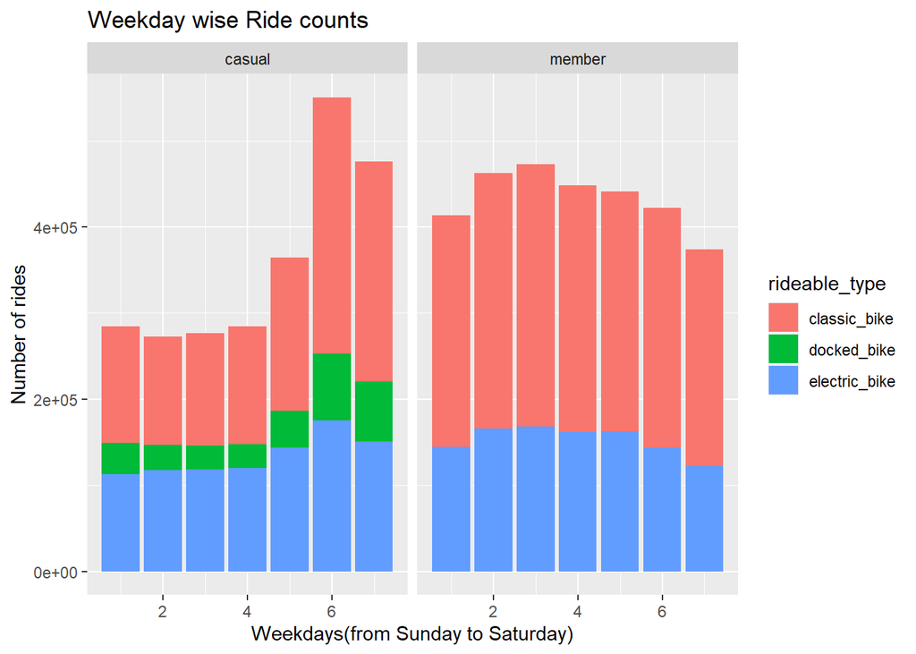

```r
ggplot(data = df) +
  geom_bar(mapping = aes(x=day_of_week,fill=rideable_type))+
  facet_wrap(~member_casual)+
  labs(title = "Weekday wise Ride counts", x = "Weekdays(from Sunday to Saturday)", y = "Number of rides")
```

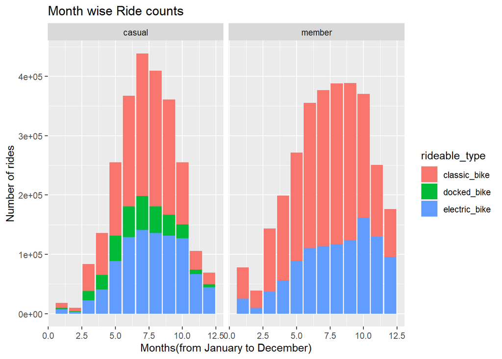

```r
ggplot(data = df) +
  geom_bar(mapping = aes(x=day_of_month,fill=rideable_type))+
  facet_wrap(~member_casual)+
  labs(title = "Month wise Ride counts", x = "Months(from January to December)", y = "Number of rides")
```

**Observation :-**  
From the above graph we can say that **casual riders use rides mostly in 3rd quarter of the year**.

Now lets plot the difference between the average ride lengths of each ride taken by annual members and casual riders in the days of the week of each month.

```r
# firstly we group the data based on monthly ,weekly, member type details then find the average ride length
temp <- df%>%
  group_by(day_of_month,day_of_week,member_casual)%>%
  summarise(avg_ride_length = mean(ride_length))
```

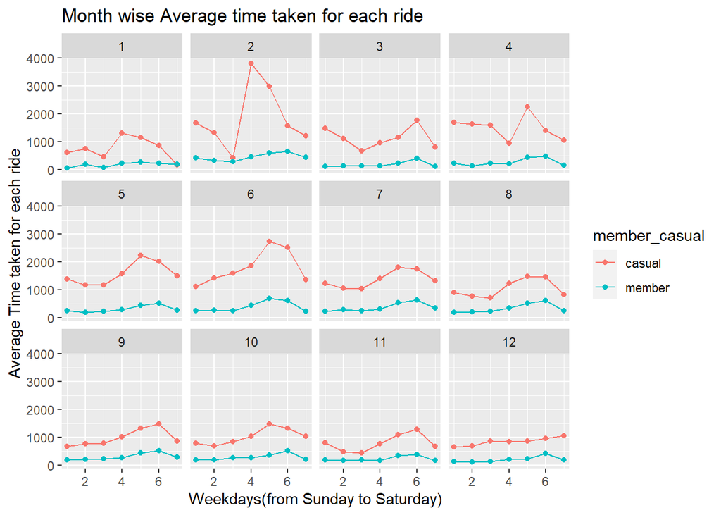

```r
ggplot(data = temp, aes(x = day_of_week, y = avg_ride_length, colour = member_casual)) +
  geom_point() + geom_line()+
  facet_wrap(~day_of_month)+
  labs(title = "Month wise Average time taken for each ride",x = "Weekdays(from Sunday to Saturday)", y = "Average Time taken for each ride")
```

**Observation :-**  
As we can see from the above graph that on an average scale **casual riders take more time for each ride than the annual members**.

Now lets analyze average ride tame taken while using different rideable types.

```r
# firstly we group the data based on week day, member type, rideable type details then find the average ride length
temp <- df%>%
  group_by(day_of_week,member_casual,rideable_type)%>%
  summarise(avg_ride_length = mean(ride_length))
```

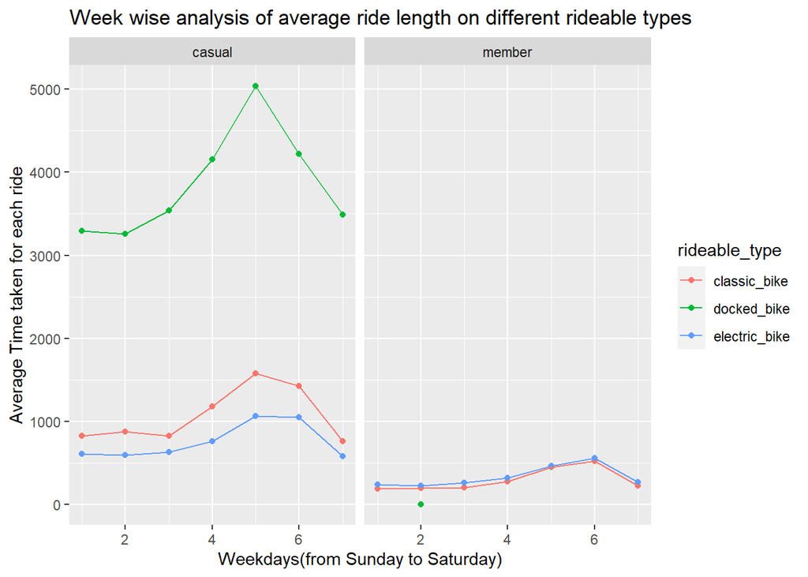

```r
ggplot(data = temp, aes(x = day_of_week, y = avg_ride_length, colour = rideable_type)) +
  geom_point() + geom_line()+
  facet_wrap(~member_casual)+
  labs(title = "Week wise analysis of average ride length on different rideable types",x = "Weekdays(from Sunday to Saturday)", y = "Average Time taken for each ride")
```

**Observation:-**  
Firstly we see that **annual members usage of docked bikes is very low**.  
On an average casual riders take more time on each rides but **casual riders take the highest time for each ride while using docked bikes**.

## Summary

Difference between casual riders and annual members in the usage of Cyclistic bikes :-

| Casual riders | Annual members |
| --- | --- |
| Average time taken for each ride is larger than annual members. | Average time taken for each ride is low compared to casual riders. |
| Number of rides are more on Friday. | Rides are consistent all over the week. |
| Number of rides are high in 3rd quarter of a year. | Number of rides in 1st,2nd and 4th quarters of the year are high compared to casual riders. |
| More than 50 % of casual riders ride in less than 13 % of the stations. | Annual members are spread more consistently than casual members. |
| Uses all types of rides. | classic and electric bikes are mostly used docked bikes are almost not used at all. |
| Average Time taken on docked bikes is extremely high compared to other ride types. | Average time taken by electric, classic bikes are almost similar. |
| 10% of casual riders take round trips. | Only 3% of annual members take round trips. |

## Recommendations for maximizing annual memberships

1. Reducing ride charges per hour for members can increase the attraction for casual riders.
2. Providing weekend sales on Friday,Saturday and Sunday for members can boost the thought of having a membership in casual riders.
3. Summer sales for members can increase the number of memberships.
4. Instead on annual membership we can provide monthly membership which helps in increasing monthly memberships.
5. Increasing the number advertisements around the top 100 stations with high casual riders can attract more than 50% of the casual riders which also helps in reducing money spent on advertisements.
6. Having special offers in top 100 stations with high casual stations for annual or monthly members also increases the chances of buying a membership.
7. Decreasing hourly charge or cost per ride for annual or monthly members on Docked bikes is also a chance for increasing memberships.
8. Reduce charges for round trips for members.